# ICU Data Analysis

```r
#load data
load("icu.Rdata")

#load libraries
library(tidyverse)
```

```r
#view the data
glimpse(icu)
```

```
Rows: 200
Columns: 20
$ vital.status <fct> lived, lived, lived, lived, lived, li...
$ age          <int> 27, 59, 77, 54, 87, 69, 63, 30, 35, 7...
$ gender       <fct> female, male, male, male, female, mal...
$ race         <fct> white, white, white, white, white, wh...
$ service      <fct> medical, medical, surgical, medical, ...
$ cancer       <fct> no, no, no, no, no, no, no, no, no, y...
$ renal        <fct> no, no, no, no, no, no, no, no, no, n...
$ infect.prob  <fct> yes, no, no, yes, yes, yes, no, no, n...
$ cpr          <fct> no, no, no, no, no, no, no, no, no, n...
$ sys          <int> 142, 112, 100, 142, 110, 110, 104, 14...
$ hr           <int> 88, 80, 70, 103, 154, 132, 66, 110, 6...
$ previous     <fct> no, yes, no, no, yes, no, no, no, no,...
$ type         <fct> emergency, emergency, elective, emerg...
$ fracture     <fct> no, no, no, yes, no, no, no, no, no, ...
$ PO2          <fct> > 60, > 60, > 60, > 60, > 60, < 60, >...
$ PH           <fct> < 7.25, < 7.25, < 7.25, < 7.25, < 7.2...
$ PCO2         <fct> > 45, > 45, > 45, > 45, > 45, > 45, >...
$ bicarb       <fct> > 18, > 18, > 18, > 18, > 18, < 18, >...
$ creat        <fct> < 2.0, < 2.0, < 2.0, < 2.0, < 2.0, < ...
$ conscious    <fct> no coma/stupor, no coma/stupor, no co...
```

Preliminary Visualizations of Variables

```r
#Independent Variable
table(icu$vital.status)
```

```
lived  died
  160    40
```

```r
#Demographics
table(icu$age)
```

```
16 17 18 19 20 21 23 24 25 27 28 30 31 32 34 35 36 40 41 42 45
 2  3  4  4  5  3  4  1  1  1  1  1  1  2  1  2  1  4  3  1  2
46 47 48 49 50 51 52 53 54 55 57 58 59 60 61 62 63 64 65 66 67
 3  3  3  3  3  2  1  3  2  8  2  2  3  7  4  2  5  6  4  5  5
68 69 70 71 72 73 74 75 76 77 78 79 80 82 83 84 85 87 88 89 91
 6  7  6  6  5  4  2  8  4  6  4  1  3  2  1  1  1  2  4  1  2
92
 1
```

```r
table(icu$race)
```

```
white black other
  175    15    10
```

```r
table(icu$gender)
```

```
  male female
   124     76
```

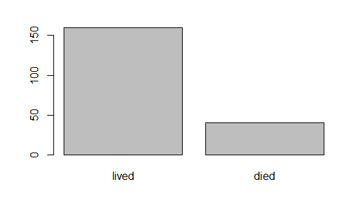

```r
#Barplots of demographics and y-variables
barplot(table(icu$vital.status))
```

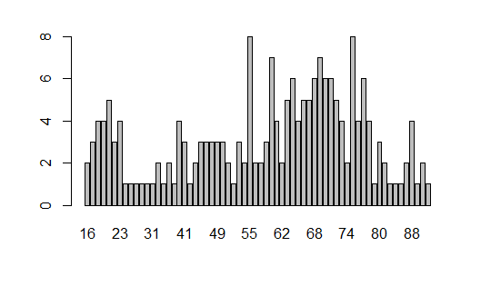

```r
barplot(table(icu$age))
```

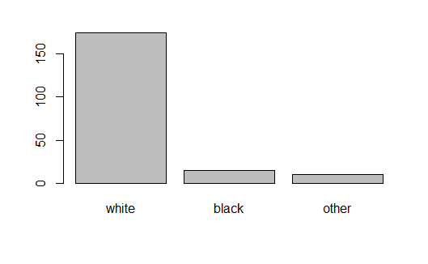

```r
barplot(table(icu$race))
```

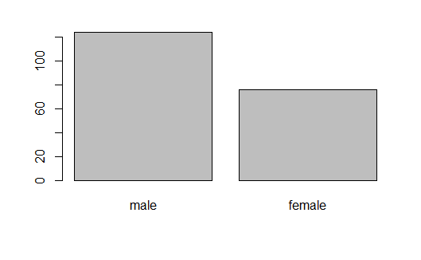

```r
barplot(table(icu$gender))
```

The study population is primarily white males between the ages of 55 and 75. The majority of patients also survived after their visit to the ICU.

The percentages of patients in each demographic category have been calculated below:

```r
#Race : White, Black, and other
race_stats <- c(175/200, 15/200, 10/200)
race_stats
```

```
[1] 0.875 0.075 0.050
```

```r
#Gender : Male and Female
gender_stats <- c(124/200, 76/200)
gender_stats
```

```
[1] 0.62 0.38
```

```r
#Vital Status : Lived and Died
vital_stats <- c(160/200, 40/200)
vital_stats
```

```
[1] 0.8 0.2
```

It can be concluded that 87.5% of the patients are white whereas only 7.5% are black. The calculations additionally show us that 62% are male and 38% of the patients are female. Lastly, 80% of the ICU patients survived following their hospital discharge and 20% died.

```r
#General factors
table(icu$conscious)
```

```
no coma/stupor    deep stupor           coma
           185              5             10
```

```r
table(icu$previous)
```

```
 no yes
170  30
```

```r
table(icu$service)
```

```
 medical surgical
      93      107
```

```r
table(icu$type)
```

```
 elective emergency
       53       147
```

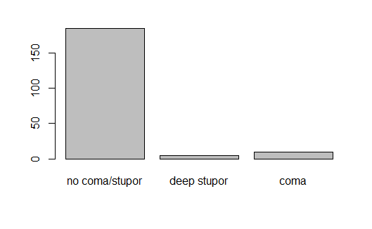

```r
#Barplots of general factors
barplot(table(icu$conscious))
```

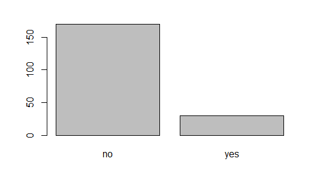

```r
barplot(table(icu$previous))
```

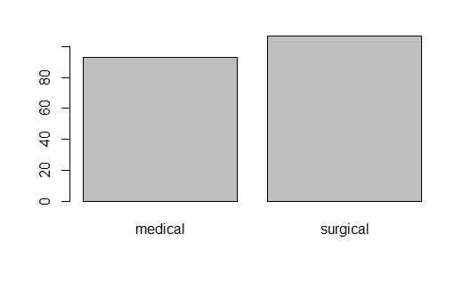

```r
barplot(table(icu$service))
```

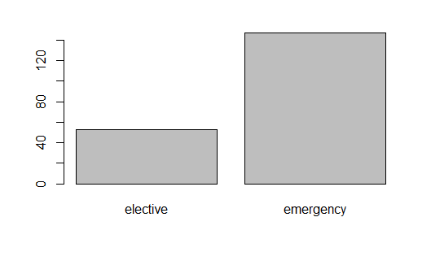

```r
barplot(table(icu$type))
```

The percentages of patients in each general category have been calculated below:

```r
#Conscious : No coma/stupor, deep stupor, or coma
cons_stats <- c(185/200, 5/200, 10/200)
cons_stats
```

```
[1] 0.925 0.025 0.050
```

```r
#Previous : No or yes
prev_stats <- c(170/200, 30/200)
prev_stats
```

```
[1] 0.85 0.15
```

```r
#Service : Medical or Surgical
serv_stats <- c(93/200, 107/200)
serv_stats
```

```
[1] 0.465 0.535
```

```r
#Type : Elective or Emergency
type_stats <- c(53/200, 147/200)
type_stats
```

```
[1] 0.265 0.735
```

```r
#Arterial Blood Gas factors
table(icu$PH)
```

```
< 7.25 > 7.25
   187     13
```

```r
table(icu$PCO2)
```

```
> 45 < 45
 180   20
```

```r
table(icu$bicarb)
```

```
> 18 < 18
 185   15
```

```r
table(icu$PO2)
```

```
> 60 < 60
 184   16
```

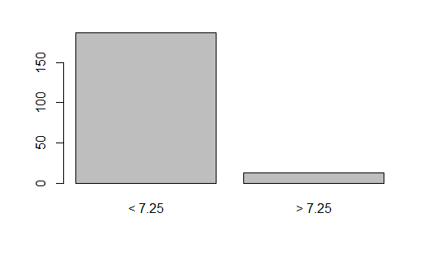

```r
#Plots of medical factors
barplot(table(icu$PH))
```

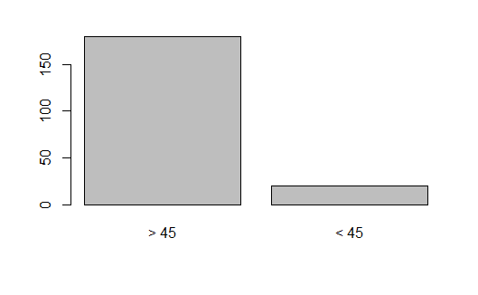

```r
barplot(table(icu$PCO2))
```

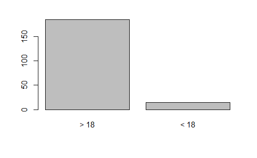

```r
barplot(table(icu$bicarb))
```

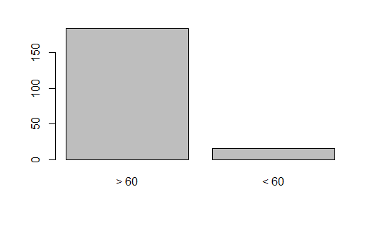

```r
barplot(table(icu$PO2))
```

Study the relationships between the variables:

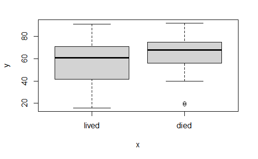

```r
#Plot the relationship between vital status and age
plot(icu$vital.status, icu$age)
```

It is important to note that the vital.status variable is binary and the distribution of the age of people in this data set is highest between the ages of 55-75. This is important when analyzing the vital status variable because there is a largely different frequency for each age group. Based on the plot between both variables, it is clear that as people get older, their chance of dying is much higher when compared to patients that are younger. We can see that the mean of people that died is roughly 70 whereas, the mean the people that lived is closer to 60. It is also important to note that there are two outliers in the people that died. This again shows that it was rare to have very young people die.

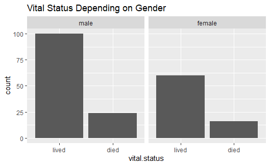

```r
#Plot the relationship between vital status and gender
icu %>%
  select(vital.status, gender) %>%
  ggplot() +
  geom_bar(aes(x=vital.status)) +
  facet_grid(~gender) +
  labs(title = "Vital Status Depending on Gender")
```

This graph illustrates a patient’s vital status depending on their gender. It can be concluded that more males survived compared to females.

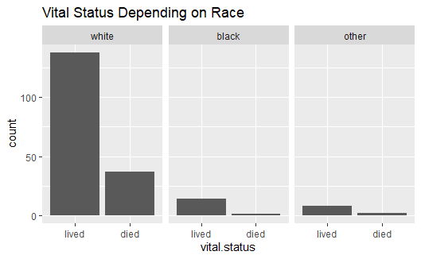

```r
#Plot the relationship between vital status and race
icu %>%
  select(vital.status, race) %>%
  ggplot() +
  geom_bar(aes(x=vital.status)) +
  facet_grid(~race) +
  labs(title = "Vital Status Depending on Race")
```

It can be concluded that more white people survived after visiting the ICU when compared to other races. It is also important to recognize that there is a large difference between the number of white patients compared to minority groups. This large numerical difference in distributions can largely impact the outcome.

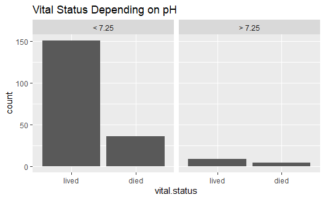

```r
#Plot the relationship between vital status and race
icu %>%
  select(vital.status, PH) %>%
  ggplot() +
  geom_bar(aes(x=vital.status)) +
  facet_grid(~PH) +
  labs(title = "Vital Status Depending on pH")
```

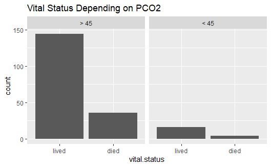

```r
#Plot the relationship between vital status and PC02
icu %>%
  select(vital.status, PCO2) %>%
  ggplot() +
  geom_bar(aes(x=vital.status)) +
  facet_grid(~PCO2) +
  labs(title = "Vital Status Depending on PCO2")
```

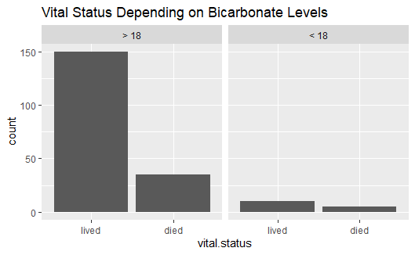

```r
#Plot the relationship between vital status and bicarb
icu %>%
  select(vital.status, bicarb) %>%
  ggplot() +
  geom_bar(aes(x=vital.status)) +
  facet_grid(~bicarb) +
  labs(title = "Vital Status Depending on Bicarbonate Levels")
```

This graph shows us that patients who had a bicarbonate levels greater than 18 had a higher chance of survival.

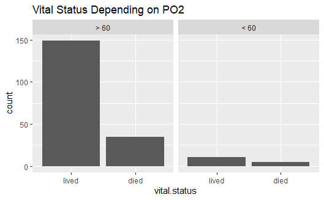

```r
#Plot the relationship between vital status and PO2
icu %>%
  select(vital.status, PO2) %>%
  ggplot() +
  geom_bar(aes(x=vital.status)) +
  facet_grid(~PO2) +
  labs(title = "Vital Status Depending on PO2")
```

This graph shows us that patients who had a PO2 levels greater than 60 had a higher chance of survival.

Check whether there is an association between demographic factors(age, gender, & race) and vital.status. Chi-square test will be used to determine whether there is an association between categorical variables.

```r
#Vitals & Age
#Create a table to understand the number of values in each section
vitals.age = table(icu$vital.status, icu$age,
                     dnn = c("Vital Status", "Age"))
addmargins(vitals.age)
```

```
            Age
Vital Status  16  17  18  19  20  21  23  24  25  27  28  30
       lived   2   3   4   3   4   3   4   1   1   1   1   1
       died    0   0   0   1   1   0   0   0   0   0   0   0
       Sum     2   3   4   4   5   3   4   1   1   1   1   1
            Age
Vital Status  31  32  34  35  36  40  41  42  45  46  47  48
       lived   1   2   1   2   1   3   2   1   2   3   3   3
       died    0   0   0   0   0   1   1   0   0   0   0   0
       Sum     1   2   1   2   1   4   3   1   2   3   3   3
            Age
Vital Status  49  50  51  52  53  54  55  57  58  59  60  61
       lived   2   1   1   1   2   2   7   1   2   3   5   3
       died    1   2   1   0   1   0   1   1   0   0   2   1
       Sum     3   3   2   1   3   2   8   2   2   3   7   4
            Age
Vital Status  62  63  64  65  66  67  68  69  70  71  72  73
       lived   2   3   5   2   5   4   6   5   5   4   4   4
       died    0   2   1   2   0   1   0   2   1   2   1   0
       Sum     2   5   6   4   5   5   6   7   6   6   5   4
            Age
Vital Status  74  75  76  77  78  79  80  82  83  84  85  87
       lived   2   3   3   6   2   1   2   2   1   1   0   1
       died    0   5   1   0   2   0   1   0   0   0   1   1
       Sum     2   8   4   6   4   1   3   2   1   1   1   2
            Age
Vital Status  88  89  91  92 Sum
       lived   3   1   1   0 160
       died    1   0   1   1  40
       Sum     4   1   2   1 200
```

```r
chisq.test(vitals.age)
```

```
Chi-squared approximation may be incorrect
```

```
    Pearson's Chi-squared test

data:  vitals.age
X-squared = 54.435, df = 63, p-value = 0.7705
```

```r
#Vitals & Gender
#Create a table to understand the number of values in each section
vitals.gender = table(icu$vital.status, icu$gender,
                     dnn = c("Vital Status", "Gender"))
addmargins(vitals.gender)
chisq.test(vitals.gender)
```

[output not shown]

The p-value for vitals and gender is 0.913, which is not less than 0.05 so we cannot reject our null hypothesis. This means that there is no association between gender and vital status. The p-value is extremely high which does not mean significance.

```r
#Vitals & Race
#Create a table to understand the number of values in each section
vitals.race = table(icu$vital.status, icu$race,
                     dnn = c("Vital Status", "Race"))
addmargins(vitals.race)
chisq.test(vitals.race)
```

[output not shown]

The Arterial Blood Gas(ABG) values (pH, PO2, PCO2, & bicarbonate) will be checked in order to see whether there is an association with vital.status.

```r
#ABG & Vital
#Vitals & PO2
vitals.po2 = table(icu$vital.status, icu$PO2,
                     dnn = c("Vital Status", "Oxygen Partial Pressure"))
addmargins(vitals.po2)
```

```
            Oxygen Partial Pressure
Vital Status > 60 < 60 Sum
       lived  149   11 160
       died    35    5  40
       Sum    184   16 200
```

```r
chisq.test(vitals.po2)
```

```
Chi-squared approximation may be incorrect
```

```
    Pearson's Chi-squared test with Yates' continuity
    correction

data:  vitals.po2
X-squared = 0.71756, df = 1, p-value = 0.3969
```

The p-value for vitals and PO2 is 0.3969, which is not less than 0.05 so we cannot reject our null hypothesis. This means that there is no association between PO2 and vital status.

```r
#Vitals & PH
vitals.ph = table(icu$vital.status, icu$PH,
                     dnn = c("Vital Status", "Normal Blood pH"))
addmargins(vitals.ph)
```

```
            Normal Blood pH
Vital Status < 7.25 > 7.25 Sum
       lived    151      9 160
       died      36      4  40
       Sum      187     13 200
```

```r
chisq.test(vitals.ph)
```

```
Chi-squared approximation may be incorrect
```

```
    Pearson's Chi-squared test with Yates' continuity
    correction

data:  vitals.ph
X-squared = 0.4165, df = 1, p-value = 0.5187
```

```r
#Vitals & PCO2
vitals.pco2 = table(icu$vital.status, icu$PCO2,
                     dnn = c("Vital Status", "Carbon Dioxide Partial Pressure"))
addmargins(vitals.pco2)
```

```
            Carbon Dioxide Partial Pressure
Vital Status > 45 < 45 Sum
       lived  144   16 160
       died    36    4  40
       Sum    180   20 200
```

```r
chisq.test(vitals.pco2)
```

```
Chi-squared approximation may be incorrect
```

```
    Pearson's Chi-squared test

data:  vitals.pco2
X-squared = 0, df = 1, p-value = 1
```

The p-value for vitals and PCO2 is 1, which is not less than 0.05 so we cannot reject our null hypothesis. This means that there is no association between PCO2 and vital status.

```r
#Vitals & bicarb
vitals.bicarb = table(icu$vital.status, icu$bicarb,
                     dnn = c("Vital Status", "Bicarbonate Level"))
addmargins(vitals.bicarb)
```

```
            Bicarbonate Level
Vital Status > 18 < 18 Sum
       lived  150   10 160
       died    35    5  40
       Sum    185   15 200
```

```r
chisq.test(vitals.bicarb)
```

```
Chi-squared approximation may be incorrect
```

```
    Pearson's Chi-squared test with Yates' continuity
    correction

data:  vitals.bicarb
X-squared = 1.0135, df = 1, p-value = 0.3141
```

The p-value for vitals and bicarb is 0.3141, which is not less than 0.05 so we cannot reject our null hypothesis. This means that there is no association between bicarbonate levels and vital status.

P-values: PO2 -> 0.3969 PH -> 0.5187 PCO2 -> 1 bicarb -> 0.3141

Based off of the chi-square tests, none of the ABG measures are associated with vital status because all of the p-values are greater than 0.05. The conclusion can be made that a patients outcome after visiting the ICU will not be significantly affected by PO2, PH, PCO2, or bicarbonate levels.

The other general factors that can impact vital status will also be considered and their association with the predictor variable will be analyzed.

```r
#Vitals & Conscious
vitals.cons = table(icu$vital.status, icu$conscious,
                     dnn = c("Vital Status", "Conscious"))
addmargins(vitals.cons)
```

```
            Conscious
Vital Status no coma/stupor deep stupor coma Sum
       lived            158           0    2 160
       died              27           5    8  40
       Sum              185           5   10 200
```

```r
chisq.test(vitals.cons)
```

```
Chi-squared approximation may be incorrect
```

```
    Pearson's Chi-squared test

data:  vitals.cons
X-squared = 45.878, df = 2, p-value = 1.091e-10
```

The p-value for vitals and conscious is 1.091e-10, which is much smaller than 0.05 so we can reject our null hypothesis. This means that there is an association between conscious level and vital status.

```r
#Vitals & Previous
vitals.prev = table(icu$vital.status, icu$previous,
                     dnn = c("Vital Status", "Previous"))
addmargins(vitals.prev)
```

```
            Previous
Vital Status  no yes Sum
       lived 137  23 160
       died   33   7  40
       Sum   170  30 200
```

```r
chisq.test(vitals.prev)
```

```
    Pearson's Chi-squared test with Yates' continuity
    correction

data:  vitals.prev
X-squared = 0.061275, df = 1, p-value = 0.8045
```

The p-value for vitals and previous is 0.8045, which is not less than 0.05 so we cannot reject our null hypothesis. This means that there is no association between previous and vital status.

```r
#Vitals & Service
vitals.serv = table(icu$vital.status, icu$service,
                     dnn = c("Vital Status", "Service"))
addmargins(vitals.serv)
```

```
            Service
Vital Status medical surgical Sum
       lived      67       93 160
       died       26       14  40
       Sum        93      107 200
```

```r
chisq.test(vitals.serv)
```

```
    Pearson's Chi-squared test with Yates' continuity
    correction

data:  vitals.serv
X-squared = 5.9806, df = 1, p-value = 0.01446
```

The p-value for vitals and service is 0.01446, which is less than 0.05 so we can reject our null hypothesis. This means that there is an association between service and vital status.

```r
#Vitals & Type
vitals.typ = table(icu$vital.status, icu$type,
                     dnn = c("Vital Status", "Type"))
addmargins(vitals.typ)
```

```
            Type
Vital Status elective emergency Sum
       lived       51       109 160
       died         2        38  40
       Sum         53       147 200
```

```r
chisq.test(vitals.typ)
```

```
    Pearson's Chi-squared test with Yates' continuity
    correction

data:  vitals.typ
X-squared = 10.527, df = 1, p-value = 0.001177
```

The p-value for vitals and type is 0.001177, which is less than 0.05 so we can reject our null hypothesis. This means that there is an association between type and vital status.

```r
#ICU & Chronic Renal Failure
icu.renal = table(icu$vital.status, icu$renal,
                     dnn = c("Vital Status", "Renal"))
addmargins(icu.renal)
```

```
            Renal
Vital Status  no yes Sum
       lived 149  11 160
       died   32   8  40
       Sum   181  19 200
```

```r
chisq.test(icu.renal)
```

```
Chi-squared approximation may be incorrect
```

```
    Pearson's Chi-squared test with Yates' continuity
    correction

data:  icu.renal
X-squared = 4.976, df = 1, p-value = 0.0257
```

The p-value for vitals and renal is 0.0257, which is less than 0.05 so we can reject our null hypothesis. This means that there is an association between renal and vital status.

```r
#ICU & Probable Infection
icu.infect = table(icu$vital.status, icu$infect.prob,
                     dnn = c("Vital Status", "Probable Infection"))
addmargins(icu.infect)
```

```
            Probable Infection
Vital Status  no yes Sum
       lived 100  60 160
       died   16  24  40
       Sum   116  84 200
```

```r
chisq.test(icu.infect)
```

```
    Pearson's Chi-squared test with Yates' continuity
    correction

data:  icu.infect
X-squared = 5.7587, df = 1, p-value = 0.01641
```

```r
summary(glm(vital.status ~ age + service + renal + infect.prob, data = icu, family=binomial(link = "logit")))
```

```
Call:
glm(formula = vital.status ~ age + service + renal + infect.prob,
    family = binomial(link = "logit"), data = icu)

Deviance Residuals:
    Min       1Q   Median       3Q      Max
-1.5217  -0.6710  -0.5166  -0.2781   2.5773

Coefficients:
                Estimate Std. Error z value Pr(>|z|)
(Intercept)     -2.96348    0.75757  -3.912 9.16e-05 ***
age              0.02559    0.01141   2.244   0.0248 *
servicesurgical -0.80716    0.39248  -2.057   0.0397 *
renalyes         0.80719    0.52998   1.523   0.1277
infect.probyes   0.60780    0.38409   1.582   0.1136
---
Signif. codes:  0 ‘***’ 0.001 ‘**’ 0.01 ‘*’ 0.05 ‘.’ 0.1 ‘ ’ 1

(Dispersion parameter for binomial family taken to be 1)

    Null deviance: 200.16  on 199  degrees of freedom
Residual deviance: 179.85  on 195  degrees of freedom
AIC: 189.85

Number of Fisher Scoring iterations: 5
```

Regression Equation: log_odds = -2.96348 + 0.02559*age + -0.80716*servicesurgical + 0.80719*renalyes + 0.60780*infect.probyes

The p-values for two variable in this model is statistically significant, so a better model is required.

```r
#Logistic regression will be used because vital status is a binary variable
summary(glm(vital.status ~ renal + infect.prob + age, data = icu, family = binomial(link = "logit")))
```

```
Call:
glm(formula = vital.status ~ renal + infect.prob + age, family = binomial(link = "logit"),
    data = icu)

Deviance Residuals:
    Min       1Q   Median       3Q      Max
-1.4160  -0.7125  -0.5545  -0.3385   2.4126

Coefficients:
               Estimate Std. Error z value Pr(>|z|)
(Intercept)    -3.29684    0.73184  -4.505 6.64e-06 ***
renalyes        0.94835    0.52130   1.819   0.0689 .
infect.probyes  0.77453    0.37195   2.082   0.0373 *
age             0.02329    0.01095   2.126   0.0335 *
---
Signif. codes:  0 ‘***’ 0.001 ‘**’ 0.01 ‘*’ 0.05 ‘.’ 0.1 ‘ ’ 1

(Dispersion parameter for binomial family taken to be 1)

    Null deviance: 200.16  on 199  degrees of freedom
Residual deviance: 184.20  on 196  degrees of freedom
AIC: 192.2

Number of Fisher Scoring iterations: 5
```

Regression Equation:

log_odds = -3.29684 + 0.94835*renalyes + 0.77453*infect.probyes + 0.02329*age

It is important to note that renalyes has a p-value that is slightly above 0.05, so it is not completely significant.

```r
#The only value that needs to be changed is infection probable, so the other values are arbitrary as long as both patients are the same otherwise
#Each variable will have a 0 if a patient has that attribute and 0 if they do not

#Odds of Mortality given Infection Probable
log_odds_inf = -3.29684 + 0.94835*0 + 0.77453*1 + 0.02329*20
odds_inf = exp(log_odds_inf)
paste("log odds: ", log_odds_inf, sep=" ")
```

```
[1] "log odds:  -2.05651"
```

```r
paste("odds: ", odds_inf, sep=" ")
```

```
[1] "odds:  0.127899561354572"
```

```r
#Odds of Mortality given No Infection Probable
log_odds_no = -3.29684 + 0.94835*0 + 0.77453*0 + 0.02329*20
odds_no = exp(log_odds_no)
paste("log odds: ", log_odds_no, sep=" ")
```

```
[1] "log odds:  -2.83104"
```

```r
paste("odds: ", odds_no, sep=" ")
```

```
[1] "odds:  0.0589515122047222"
```